# Introduction to missingHE

The package `missingHE` is specifically designed to facilitate the implementation of different types of missing data models to conduct trial-based health economic evaluations from a **Bayesian** statistical perspective. The main justification for the use of Bayesian models in economic evaluations is related to the decision-making nature of the problem, which imposes the need to assess the impact of different sources of uncertainty both on the statistical and cost-effectiveness results.

While frequentist methods are more popular among practitioners, they typically require *ad-hoc* steps for quantifying the uncertainty around the estimated quantities of interest. Examples include the need to perform some form of bootstrapping to generate replications to generate standard cost-effectiveness outputs (e.g. cost-effectiveness planes and acceptability curves), or the use of multiple imputations to account for missingness uncertainty. Although these steps can lead to statistically valid results, in practice, when the complexity of the model is increased (for example to deal with common statistical issues of the data such as correlation, clustering, missingness or skewenss), then the task of coherently specifying all the steps within a frequentist framework may become incredibly difficult to check. The Bayesian approach, instead, allows fit the model of interest while *simultaneously* handling all the different issues related to the data as well as to correctly propagating and quantifying uncertainty for each unobserved quantitiy in the model (being either a parameter or a missing value).

Different types of missing data models exist, each with its own advantages and disadvantages when it comes down to the strategy used to handle missingness. `missingHE` implements three main types of missingness models: **selection** models, **pattern mixture** models, and **hurdle** models. All models are implemented via *Markov Chain Monte Carlo* (MCMC) algorithms based on the `BUGS` language and the Bayesian program `JAGS`. For techincal details and an overview of the software see http://mcmc-jags.sourceforge.net/.

For each model, the package provides a series of ancillary functions to allow the user to assess convergence, check the fit to the data, extract and summarise the results. This document is a brief tutorial to help getting started with the package and its main functions. Throughout the tutorial, we will use the built-in dataset called `MenSS` as a toy example, which is directly available when installing and loading `missingHE` in your `R` workspace. It is important to remember that `missingHE` only allows the analysis of two-arm studies (comparison of more than two intervantions is not currently supported) and is designed to handle missing values only in the outcome variables (no missing values in the covariates are allowed).

If you would like to have more information on the package, or would like to point out potential issues in the current version, feel free to contact the maintainer at ucakgab@ucl.ac.uk. Suggestions on how to improve the package are also very welcome.

## Data: MenSS

The Men’s Safer Sex (MenSS) trial was a pilot randomised controlled trial conducted on young men at risk of sexually transmitted infections (STIs). A total of $159$ individuals were enrolled in the trial, $75$ in the comparator group ($t=1$, standard of care) and $84$ in the reference group ($t=2$, standard of care plus online intervention). Clinical and health economic outcomes were collected via self-reported questionnaires at baseline, $3$, $6$, and $12$ months follow-ups.

- Health economic data included utility scores based on health-related quality of life (from EQ5D-3L) and costs based on resource use information (from CSRI). QALYs and Total costs were then derived from aggregating the utility and cost data using the *area under the curve* method and by summing up the follow-up costs over the trial duration, respectively.
- Clinical data included number of instances of unprotected sex and whether or not each individual was associated with an STI diagnosis.

The dataset `MenSS` includes the main variables of interest for the economic evaluations, including the individual-level QALYs and baseline utilities, Total costs, as well as the number of instances of unprotected sex and the STI diagosis indicator at baseline and $12$ months follow-up. Additional baseline variables provided are: id, treatment indicator, age, ethnicity, employment status and site. We can look at a summary description of the variables in `MenSS` by using the `str` function.

```
> str(MenSS)
#> 'data.frame':    159 obs. of  13 variables:
#>  $ id        : int  1 2 3 4 5 6 7 8 9 10 ...
#>  $ u.0       : num  0.725 0.848 0.848 1 0.796 ...
#>  $ e         : num  NA 0.924 NA NA NA 0.943 NA NA NA 0.631 ...
#>  $ c         : num  NA 0 NA NA NA 0 NA NA NA 516 ...
#>  $ age       : int  23 23 27 27 18 25 48 30 24 27 ...
#>  $ ethnicity : Factor w/ 2 levels "0","1": 1 1 2 1 1 2 2 2 2 1 ...
#>  $ employment: Factor w/ 2 levels "0","1": 1 2 1 1 1 2 2 2 2 2 ...
#>  $ t         : int  1 1 1 1 1 1 1 1 1 1 ...
#>  $ sex_inst.0: num  25 30 6 20 1 20 6 4 1 12 ...
#>  $ sex_inst  : int  NA 50 3 0 99 NA 20 NA NA NA ...
#>  $ sti.0     : int  0 0 0 0 0 1 0 0 1 0 ...
#>  $ sti       : int  1 0 0 0 0 0 0 0 0 0 ...
#>  $ site      : Factor w/ 3 levels "1","2","3": 1 3 3 1 3 1 1 1 1 2 ...
```

We can look at the empirical distributions of the data, for example the QALYs ($e$) and Total costs ($c$) variables, by treatment arm to have a general idea about what type of issues seem to be relevant for our analysis. Remember that, when using your own dataset, variables must be assigned specific names when using the functions from `missingHE`. In particular, the treatment arm indicator should take value $1$ and $2$ for the control and intervention group, while the effectiveness and cost variables should be assigned the names $e$ and $c$, respectively.

```
> par(mfrow=c(2,2))
> hist(MenSS$e[MenSS$t==1], main = "QALYs - Control")
> hist(MenSS$e[MenSS$t==2], main = "QALYs - Intervention")
> hist(MenSS$c[MenSS$t==1], main = "Costs - Control")
> hist(MenSS$c[MenSS$t==2], main = "Costs - Intervention")
```

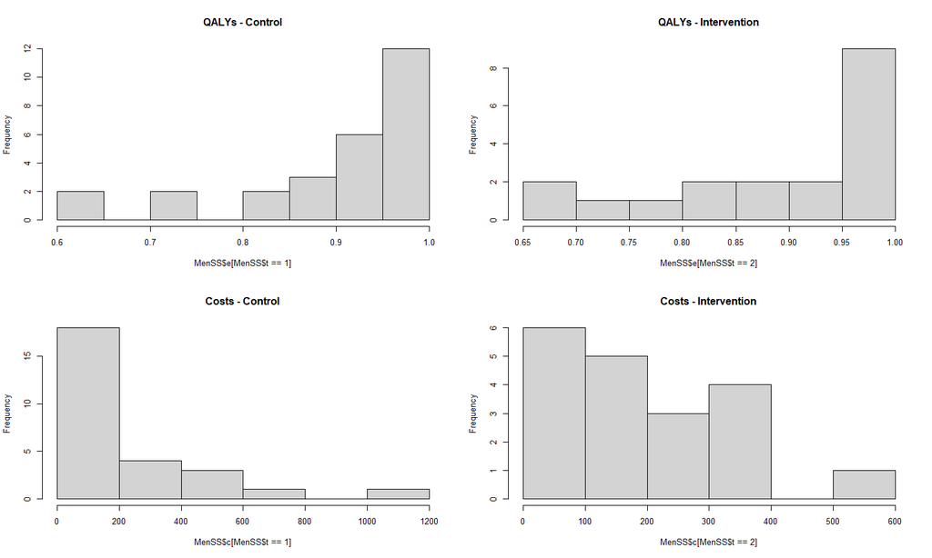

We can immediately see that non-normality seems to be relatively high in both the QALYs (negatively skewed) and Total costs (positively skewed) in each treatment group. In addition, there is a considerable amount of identical or *structural values* for both outcomes (ones for QALYs and zeros for costs), which increases the degree of skewness in our data. We can see the proportions of these structural values using the following commands

```
> #proportions of ones and zeros in the control group
> c(sum(MenSS$e[MenSS$t==1]==1, na.rm = TRUE) / length(MenSS$e[MenSS$t==1]),
+ sum(MenSS$c[MenSS$t==1]==0, na.rm = TRUE) / length(MenSS$e[MenSS$t==1]))
[1] 0.12000000 0.09333333
```

```
>
> #proportions of ones and zeros in the intervention group
> c(sum(MenSS$e[MenSS$t==2]==1, na.rm = TRUE) / length(MenSS$e[MenSS$t==2]),
+ sum(MenSS$c[MenSS$t==2]==0, na.rm = TRUE) / length(MenSS$e[MenSS$t==2]))
[1] 0.09523810 0.05952381
```

Finally, the proportions of missing values is considerably large for both outcomes and intervention groups.

```
> #proportions of missing values in the control group
> c(sum(is.na(MenSS$e[MenSS$t==1])) / length(MenSS$e[MenSS$t==1]),
+ sum(is.na(MenSS$c[MenSS$t==1])) / length(MenSS$e[MenSS$t==1]))
[1] 0.64 0.64
```

```
>
> #proportions of missing values in the intervention group
> c(sum(is.na(MenSS$e[MenSS$t==2])) / length(MenSS$e[MenSS$t==2]),
+ sum(is.na(MenSS$c[MenSS$t==2])) / length(MenSS$e[MenSS$t==2]))
[1] 0.7738095 0.7738095
```

If you inspect the data, for example using the `View()` command, you will see that the missingness patterns are exactly the same between QALYs and Total costs, which can be either observed or missing together but no other pattern occurs.

## Selection models

So, let’s start with the first type of missingness model, known as *selection models*, which can be fitted using the function `selection`. These are based on four models.

- The first two, denoted with the terms `model.eff` and `model.cost`, are the models of interest for the effectiveness ($e$) and cost ($c$) variables, where covariates can be included via a linear formula. A joint bivariate model can also be specified by including $e$ as a covariate inside the model for $c$ to account for the potential dependence between the outcomes. Alternative distributions can be selected for both variables using the arguments `dist_e` and `dist_c`. Type `help(selection)` for the list of the available distributions.
- The last two, denoted with the terms `model.me` and `model.mc` are the auxiliary models for the missingness indicators for the effects and costs, also know as **missingness mechanisms**. These are fitted to estimate the missingness probabilities using logistic regressions and allow the inclusion of covariates in the same way as the models of interest.
- The type of missingness assumptions can be specified using the argument `type`, which can be set to be either `"MAR"` (for a missing at random assumptions) or `"MNAR"` (for a missing not at random assumption). Although typically inadequate, missing completely at random (MCAR) assumptions can also be specified by fitting the model under MAR without the inclusion of covariates in any of the models.
- Optional arguments can also be specified: `n.iter` (number of MCMC iterations); `inits` (initial values - by default randomly generated); `ppc` (whether or not results for posterior predictive check should be stored - default is no); `save_model` (whether or not a .txt file of the `JAGS` code of the model should be printed in the current wd - deafult is no); `prior` (choice of prior values - default are weakly-informative).

```
> NN.sel=selection(data = MenSS, model.eff = e ~ u.0, model.cost = c ~ e,
+   model.me = me ~ age + ethnicity + employment,
+   model.mc = mc ~ age + ethnicity + employment, type = "MAR",
+   n.iter = 1000, dist_e = "norm", dist_c = "norm", ppc = TRUE)
```

The command above fits a selection model to the `MenSS` dataset assuming normal distributions for both the effectiveness and cost variables, adjusting for baseline utilities in the model of $e$ and accounting for the dependence with $e$ in the model of $c$. Missingness is handled under MAR and three baseline variables (age, ethnicity and employment status) are included in the models of `me` and `mc`. In case categorical covariates are inlcuded in the models, it is important that these should be defined as factors in the data. `missingHE` automatically decomposes these variables into a series of dummy variables which are included into the models as predictors, while also removing the one associated with the first level of the factors to avoid perfect collinearity. The argument `ppc=TRUE` allows to store the results of the model for doing some posterior checks for assessing the model performance if desired (default is `FALSE`) - see later on this.

We can print the results from the selection model, which are stored in the object `NN.sel`, by typing

```
> print(NN.sel, value.mis = FALSE, only.means = TRUE)
           mean     sd    2.5%   97.5%  Rhat n.eff
mu_c[1] 237.129 50.998 134.023 335.980 1.001  1000
mu_c[2] 185.151 38.788 107.044 262.080 1.000  1000
mu_e[1]   0.874  0.017   0.839   0.908 1.006   820
mu_e[2]   0.916  0.022   0.874   0.960 1.002   990
```

The command produces a summary statistics of the marginal mean effects ($\mu_e$) and costs ($\mu_c$) posterior distributions by treatment group, including mean, sd, $95\%$ credible interval and two MCMC diagnostic measures (`Rhat` and `n.eff`). If we set `value.mis=TRUE` and `only.means=FALSE`, then the same results are displayed for each parameter and imputed value of the model.

It is also possible to directly extract summary statistics for the regression coefficients from the model of $e$ and $c$ using the generic function `coef`, which gives

```
> coef(NN.sel, random = FALSE)
$Comparator
$Comparator$Effects
             mean    sd  lower upper
(Intercept) 0.187 0.141 -0.097 0.451
u.0         0.780 0.152  0.490 1.089

$Comparator$Costs
                mean      sd     lower    upper
(Intercept)  237.129  50.998   134.023  335.980
e           -986.507 420.947 -1849.887 -170.828


$Reference
$Reference$Effects
             mean    sd lower upper
(Intercept) 0.662 0.075 0.499 0.816
u.0         0.287 0.087 0.114 0.472

$Reference$Costs
                mean      sd    lower  upper
(Intercept)  185.151  38.788  107.044 262.08
e           -170.822 349.572 -835.884 514.79
```

The function returns the posterior mean, sd and $95\%$ bounds for each coefficient associated with the outcome models, separately by treatment (comparator and reference group) on the scale of the regression. In case normal distributions are chosen, this is the natural scale of the variables in the data but for other distributions either log or logit scales are used. See `help(selection)` for more details. When the optional argument is set `random=TRUE`, then the coefficient estimates for the random effects (if specified) are also displayed.

Finally, a summary of the cost-effectiveness results from the model can be displayed by typing

```
> summary(NN.sel)

 Cost-effectiveness analysis summary

 Comparator intervention: intervention 1
 Reference intervention: intervention 2

 Parameter estimates under MAR assumption

 Comparator intervention
                        mean     sd      LB     UB
mean effects (t = 1)   0.874  0.017   0.847  0.902
mean costs (t = 1)   237.129 50.998 149.082 319.98

 Reference intervention
                        mean     sd      LB      UB
mean effects (t = 2)   0.916  0.022    0.88   0.952
mean costs (t = 2)   185.151 38.788 118.665 249.975

 Incremental results
                   mean    sd       LB    UB
delta effects     0.042 0.028   -0.003 0.087
delta costs     -51.978 63.39 -156.004 50.04
ICER          -1243.818
```

Standard economic outputs are provided, including summary statistics for the mean effects and costs by treatment group and the incremental means and ICER between the two groups. It is also possible to use functions from the package `BCEA` to produce graphical outputs of cost-effectiveness, such as the cost-effectiveness plane and acceptability curve based on the results of the model. This can be achieved, for example by typing

```
> par(mfrow=c(1,2))
> BCEA::ceplane.plot(NN.sel$cea)
> BCEA::ceac.plot(NN.sel$cea)
```

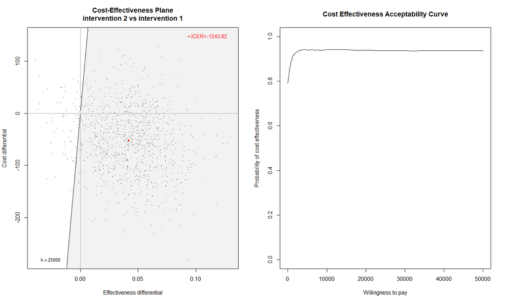

For more information on how to interpret and customise these plots, I refer to the `BCEA` package.

## Pattern mixture models

The second type of missingness model available in `missingHE` are *pattern mixture models*, which can be fitted using the function `pattern`. These are based on three models.

- The first two models are denoted with the terms `model.eff` and `model.cost`, and refert to the effectiveness and cost models in a similar way to what shown for `selection` in terms of related arguments, including the type of distributons and missingness assumptions. If the model is fitted under MAR, the argument `Delta_e` and `Delta_c` must be set to $0$. These are the priors on the sensitivity parameters which can be used to specify a MNAR assumption, whic should therefore be removed under MAR.
- However, in contrast to selection models, the models for $e$ and $c$ in `pattern` are fitted within each missingness pattern in the dataset. Patterns are defined only based on the number of individuals with observed and missing outcome data, for a total of $4$ maximum number of patterns. Parameters that cannot be identified from the data (because missing) are identified using some modelling restrictions. Two types of restrictions are available in `missingHE`: `"CC"` and `"AC"`, which can be set using the argument `restriction`. The first identifies all unidentified parameters by setting them equal to the parameters estimated from the complete cases, while the second using those estimated from the available cases (patterns where the other outcome is missing). Type `help(pattern)` for more information on the assumptions of pattern mixture models.
- Although not directly accessible from `pattern`, the function implicitly fits a model for the probability of being associated with each missingness pattern in the dataset. These are estimated using multinomial distributions and weakly-informative priors on all patterns probabilities. Posterior estimates for these parameters are then used to compute the weighted mean effects and costs across the patterns.

```
> NN.pat=pattern(data = MenSS, model.eff = e ~ u.0, model.cost = c ~ e,
+   type = "MAR", restriction = "CC", n.iter = 1000, Delta_e = 0, Delta_c = 0,
+   dist_e = "norm", dist_c = "norm", ppc = TRUE)
```

The model assumes normal distributions for both outcomes under a MAR assumption and using complete case restrictions to identify the parameters that cannot be identified from the observed data in each pattern. We can inspect the results by doing

```
> coef(NN.pat, random = FALSE)
$Comparator
$Comparator$Effects
                      mean    sd  lower upper
(Intercept) pattern1 0.177 0.141 -0.104 0.442
u.0 pattern1         0.790 0.152  0.500 1.101
(Intercept) pattern2 0.177 0.141 -0.104 0.442
u.0 pattern2         0.790 0.152  0.500 1.101
(Intercept) pattern3 0.177 0.141 -0.104 0.442
u.0 pattern3         0.790 0.152  0.500 1.101
(Intercept) pattern4 0.177 0.141 -0.104 0.442
u.0 pattern4         0.790 0.152  0.500 1.101

$Comparator$Costs
                         mean      sd     lower    upper
(Intercept) pattern1  240.664  50.559   141.894  341.652
e pattern1           -981.941 413.543 -1755.334 -146.819
(Intercept) pattern2  240.664  50.559   141.894  341.652
e pattern2           -981.941 413.543 -1755.334 -146.819
(Intercept) pattern3  240.664  50.559   141.894  341.652
e pattern3           -981.941 413.543 -1755.334 -146.819
(Intercept) pattern4  240.664  50.559   141.894  341.652
e pattern4           -981.941 413.543 -1755.334 -146.819


$Reference
$Reference$Effects
                      mean    sd lower upper
(Intercept) pattern1 0.666 0.075 0.515 0.809
u.0 pattern1         0.284 0.086 0.121 0.460
(Intercept) pattern2 0.666 0.075 0.515 0.809
u.0 pattern2         0.284 0.086 0.121 0.460
(Intercept) pattern3 0.666 0.075 0.515 0.809
u.0 pattern3         0.284 0.086 0.121 0.460
(Intercept) pattern4 0.666 0.075 0.515 0.809
u.0 pattern4         0.284 0.086 0.121 0.460

$Reference$Costs
                         mean      sd    lower   upper
(Intercept) pattern1  185.828  40.278  106.707 260.997
e pattern1           -179.191 351.793 -835.809 570.342
(Intercept) pattern2  185.828  40.278  106.707 260.997
e pattern2           -179.191 351.793 -835.809 570.342
(Intercept) pattern3  185.828  40.278  106.707 260.997
e pattern3           -179.191 351.793 -835.809 570.342
(Intercept) pattern4  185.828  40.278  106.707 260.997
e pattern4           -179.191 351.793 -835.809 570.342
```

Aggregted mean estimates over the patterns can be retrieved using `print` or, together with summary CEA results, using the `summary` command

```
> summary(NN.pat)

 Cost-effectiveness analysis summary

 Comparator intervention: intervention 1
 Reference intervention: intervention 2

 Parameter estimates under MAR assumption

 Comparator intervention
                        mean     sd      LB      UB
mean effects (t = 1)   0.873  0.017   0.846   0.901
mean costs (t = 1)   240.664 50.559 158.242 326.213

 Reference intervention
                        mean     sd      LB      UB
mean effects (t = 2)   0.917  0.023    0.88   0.953
mean costs (t = 2)   185.828 40.278 118.855 250.737

 Incremental results
                   mean     sd       LB     UB
delta effects     0.043  0.028   -0.005  0.092
delta costs     -54.836 64.173 -155.426 53.818
ICER          -1265.664
```

Standard graphical economic outputs based on the model results can again be obtained using functions from the `BCEA` package.

## Hurdle models

The last type of missingness model that can be fitted in `missingHE` are the **hurdle models**, implemented via the function `hurdle`. These are based on four models.

- The first two are the models for $e$ and $c$ and are very similar to those used in `selection`. However, hurdle models are not technically speaking missingness models in that they typically do not allow to choose among specific missingness assumptions. They consist in two-part regressions designed to handle the presence of structural values in the data. The presence/absence of structural values in the effects and costs data can be specified in the function using the arguments `se` and `sc`. They must be set to `NULL` if the structural values in one of the outcomes is absent, and must be set equal to the actual structural value if these are present.
- The last two models are fitted to two indicator variables associated with the presence or absence of a structural value for each individual in the data, denoted with the terms `model.se` and `model.sc`. These models are aimed at esitmating the probability of being associated with a structural effect and cost value using logistic regressions in a similar fashion to the models for `model.me` and `model.mc` in `selection`. Once these probabilities are esitmated, the overall mean effects and costs in each arm are obtained through a weighted average between the means of the non-structural component (obtained from the models of $e$ and $c$) and the corresponding probabilities of having a structural value.
- Due to the construction of hurdle models, the argument `type` takes different values compared to the standard MAR/MNAR assumptions in that the assumptions of the model are related to the probability of having a structural value rather than a missing value. `missingHE` allows to choose among *Structural Completely At Random* (SCAR) and *Structural At Random* (SAR) assumptions, the difference being the absence or presence of some covariate in the model for the structural probabilities. However, within a Bayesian approach, hurdle models can be extended to impute missing values in a relatively easy way in that the structural and non-structural components from the data can be effectively replicated when imputing the missing values without the need of ad-hoc imputation steps. We refer to `help(hurdle)` for more details on assumptions behind hurdle models.

```
> NN.hur=hurdle(data = MenSS, model.eff = e ~ u.0, model.cost = c ~ e,
+   model.se = se ~ 1, model.sc = sc ~ age, type = "SAR", se = 1, sc = 0,
+   n.iter = 1000, dist_e = "norm", dist_c = "norm", ppc = TRUE)
```

```
> coef(NN.hur, random = FALSE)
$Comparator
$Comparator$Effects
             mean    sd  lower upper
(Intercept) 0.315 0.195 -0.077 0.708
u.0         0.617 0.220  0.165 1.052

$Comparator$Costs
                mean      sd     lower   upper
(Intercept)  261.929  62.783   138.516 387.400
e           -759.380 486.114 -1656.729 184.005


$Reference
$Reference$Effects
            mean    sd  lower upper
(Intercept) 0.73 0.085  0.559 0.895
u.0         0.14 0.112 -0.081 0.354

$Reference$Costs
               mean      sd    lower   upper
(Intercept) 257.846  43.939  168.379 341.323
e            38.304 400.528 -736.141 799.748
```

If interest is also about the estimates for the parameters indexing the models of `se` and `sc`, the entire posterior distributions for these (as well as any other parameters of the model) can be extracted by accessing the elements named `structural_parameter_effects_fixed` and `structural_parameter_costs_fixed`, respectively. These are stored inside the `model_output` list, available by typing `NN.hur$model_output`.

Finally, results can be summarised as

```
> summary(NN.hur)

 Cost-effectiveness analysis summary

 Comparator intervention: intervention 1
 Reference intervention: intervention 2

 Parameter estimates under SAR assumption

 Comparator intervention
                        mean     sd      LB      UB
mean effects (t = 1)   0.907   0.02   0.874   0.939
mean costs (t = 1)   193.686 50.982 114.238 278.878

 Reference intervention
                        mean     sd      LB      UB
mean effects (t = 2)   0.915  0.027   0.869   0.956
mean costs (t = 2)   186.536 40.441 121.785 252.568

 Incremental results
                  mean     sd       LB     UB
delta effects    0.008  0.033   -0.044   0.06
delta costs      -7.15 65.692 -116.464 98.783
ICER          -868.657
```

and further exploration of the CEA results can be done using the package `BCEA`.

## Model assessment

Before even looking at the results of the models fitted using `selection`, `pattern` or `hurdle`, it is recommended to check for possible issues in the convergence of the MCMC algorithm which, if present, may hinder the validity of the results obtained. This is standard practice when fitting models based on iterative simulation methods, such as MCMC, where a larger number of iterations may be required to ensure the stability of the results.

`missingHE` allows to implement different types of convergence diagnostics for each type of model via the function `diagnostic`. For example, consider the selection model that we fitted before and saved into the object `NN.sel`. We can examine posterior *density plots* for the mean effects by treatment arm by typing

```
> diagnostic(NN.sel, type = "denplot", param = "mu.e", theme = NULL)
```

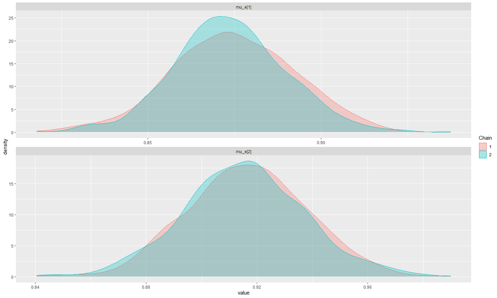

The plots do not indicate any potential issue in terms of failed convergence since estimates from both chains seem to overlap quite well (i.e. a single posterior distribution for each parameter seems to be reached).

1. The argument `type` is used to select the desired type of diagnostic measure (see `help(diagnostic)` for a list of all types available).

For example, we can look at *trace plots* for the mean costs estimated from the pattern mixture model by typing

```
> diagnostic(NN.pat, type = "traceplot", param = "mu.c", theme = NULL)
```

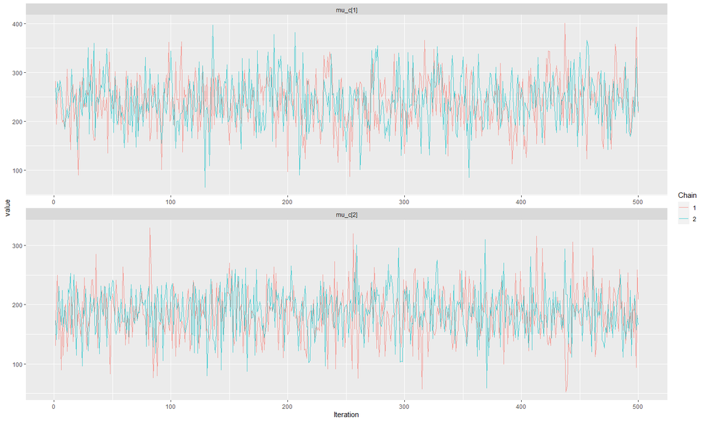

2. The argument `param` denotes the parameter for which the diagnostics should be shown. The list of parameters that can be selected varies depending on the type of model fitted (e.g. `selection` or `hurdle`) and the assumptions made (e.g. MAR or MNAR). Type `help(diagnostic)` for the full list of parameters available for each type of model and assumptions. It is also possible to set `param="all"` if the results for all parameters in the model should be displayed together.

For example, we can look at the *autocorrelation plots* for the posterior distribution of the probability of having a structural zero costs in the hurdle model by typing

```
> diagnostic(NN.hur, type = "acf", param = "p.c", theme = "base")
```

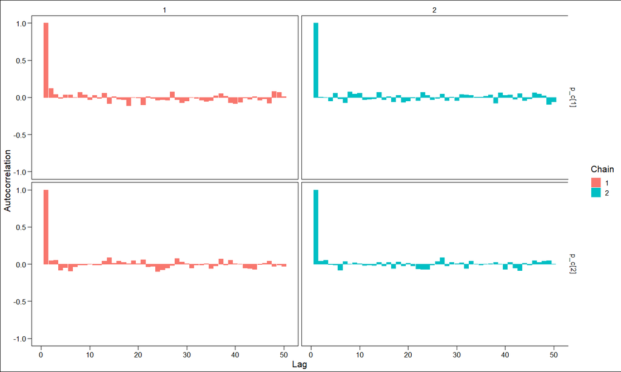

3. The argument `theme` selects the type of backgroung theme to be used for plotting, chosen among a pre-defined set of themes whose names can be seen by typing `help(diagnostic)`.

## Checking imputations

It is possible to look at how missing outcome values are imputed by each type of model using the generic function `plot` that, when applied to an object generated by `missingHE` functions, for example the model stored in `NN.sel`, produces the following output

```
> plot(NN.sel, class = "scatter", outcome = "all")
```

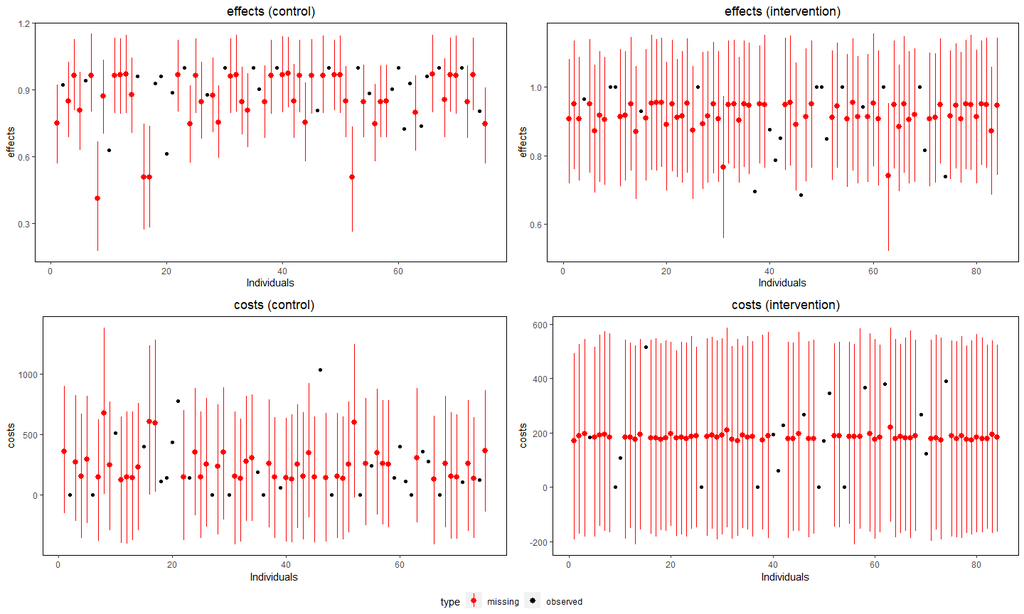

The four plots show the observed values (black dots) and the posterior distribution of the imputed values (red dots and lines) by type of outcome (effects top, costs bottom) and treatment group (control left, intervention right).

1. The argument `class` specifies what type of graphical output should be displayed, either scatter plots (`scatter` - default option) or histogram plots (`histogram`).

For example, we can show the histogram of the imputations produced by the pattern mixture model by typing

```
> plot(NN.pat, class = "histogram", outcome = "all")
```

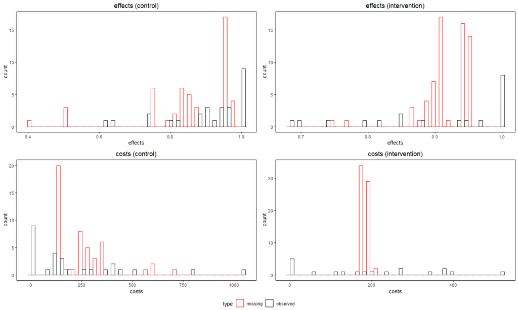

2. The argument `outcome` chooses for which outcome variable the results should be shown. Available choices include either all variables in all groups (`all` - default), only the effects or costs variables (`effects` and `costs`), only the variables in a specific group (`arm1` and `arm2`) or a combination of these.

For example, we can look at the distributions of the imputed costs in the control group for the hurdle model by typing

```
> plot(NN.hur, class = "scatter", outcome = "costs_arm1")
```

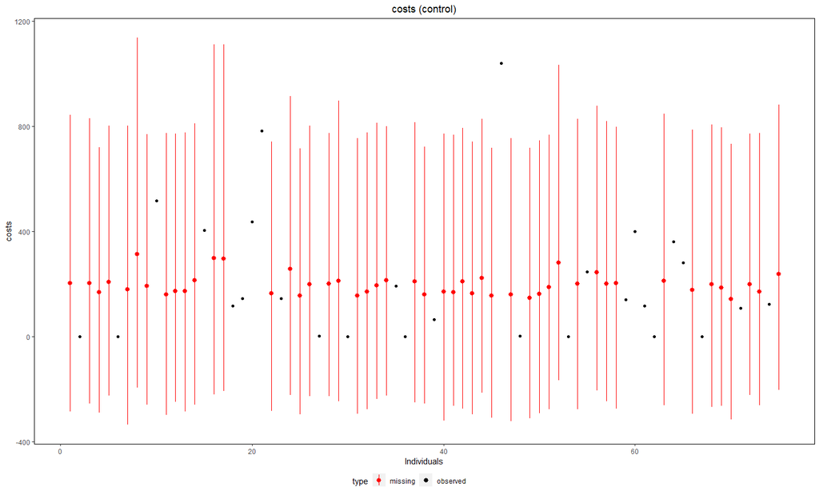

## Model comparison and fit

We can check the fit of the models to the observed data by looking at *posterior predictive checks* (PPC) and we can compare the fit of altenative model specifications via *preditive information criteria* (PIC). Both measures are really useful when checking whether or not the results from your model align with the information from the observed data and for choosing the best models among those considered.

### PPC

The idea behind PPCs consist in using the estimated parameters from your model in order to generate replications of your data which can then be compared with the observed values to detect possible inconsistencies in the replications. The main objective of these checks is to see whether the model is able to capture some apsects of the data in which you are interested (e.g. mean, skeness, proportions of structural values, etc…) which would suggest a good fit of the model.

You can implement different types of PPCs in `missingHE` using the function `ppc`. For example, we can look at replicates of the histograms of the data for the effects in the control group based on the results of the selection model by typing

```
> ppc(NN.sel, type = "histogram", outcome = "effects_arm1", ndisplay = 8)
```

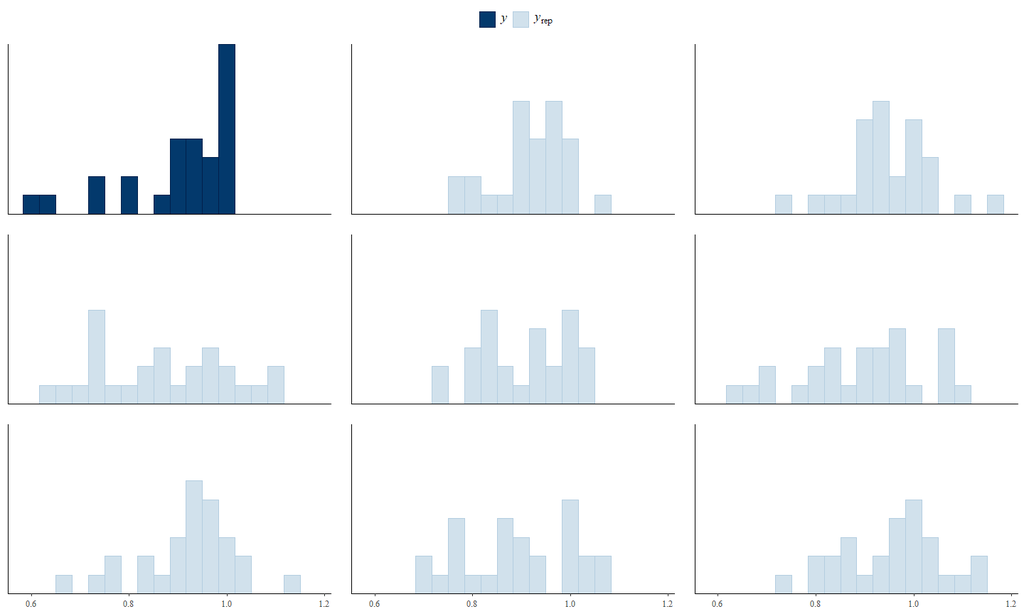

1. The argument `type` selects the type of check to display. Different types of plots can be drawn using specific names. See `help(ppc)` for the full list of choices. The argument `ndisplay` indicates the number of replications that should be displayed for the comparison.

For example, we can compare the observed and replicated kernel densities in the control group based on the results from the pattern mixture model by typing

```
> ppc(NN.pat, type = "dens", outcome = "effects_arm1", ndisplay = 8)
```

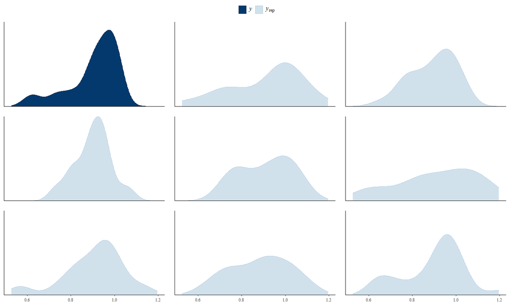

2. The argument `outcome` chooses the type of variables for which results should be displayed. Available options include: `all` for both effects and costs in each treatment group, `effects` and `costs` for the corresponding outcomes in each group, and a combination of these. See `help(ppc)` for the list of all options.

For example, we can look at overlayed densities between observed and replicated data for all variables based on the results from the hurdle model by typing

```
> ppc(NN.hur, type = "dens_overlay", outcome = "all", ndisplay = 25)
```

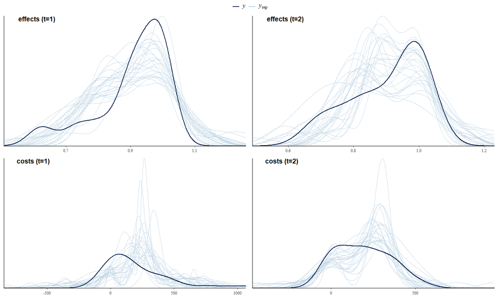

### PIC

PICs allow the comparison of the fit to the observed data form alternative model specifications using a measure calculated from a function of the loglikelihood (the *deviance*) and a penalty term for model complexity (the *effective number of parameters*). The key message is that models associated with lower PIC values have a better fit to the observed data compared with models associated with higher PIC values. It is very important that, when dealing with partially-observed data, the fit of the model can only be assessed based on the observed values. Thus, comparison by means of PICs is always partial since the fit to the unobserved values can never be checked. This is why it is generally not recommened to compare models fitted under MNAR assumptions as the comparison may be completely meaningless.

Three main types of PICs can be selected in `missingHE` via the `pic` function, which can be applied to each type of model fitted withint the package. Choices include the *Deviance Information Criterion* (DIC), the *Widely Applicable Inofrmation Criterion* (WAIC), and the *Leave-One-Out Information Criterion* (LOOIC). Among these, the latter two are typically preferred as they are calculated on the full posterior distribution of the model and do not suffer from some drawbacks (e.g. reparameterisation) that may instead affect the DIC. Type `help(pic)` for more details about these measures.

For example, we can compare the fit to the observed data from the three models fitted using WAIC by typing

```
> pic_sel <- pic(NN.sel, criterion = "waic", module = "both")
> pic_pat <- pic(NN.pat, criterion = "waic", module = "both")
> pic_hur <- pic(NN.hur, criterion = "waic", module = "both")
>
> #print results
> c(pic_sel$waic, pic_pat$waic, pic_hur$waic)
[1]  539.2823  539.0758 -465.3983
```

The results indicate a much better fit of the hurdle model compared to the others, with a WAIC estimate which is negative. This is reasonable since the hurdle model can capture the structural values which are instead ignored by selection or pattern mixture models. However, hurdle model do not allow to explore MNAR and therefore thier results are entirely based on MAR.

The argument `criterion` specifies the type of PIC to use for the assessment, while `module` indicates for which parts of the model the measure should be evaluated. Choices are: `total` (default), which is useful if comparing models having the same structure; `both` for using both the models for $e$ and $c$ but not the auxiliary models (e.g. those for `me` and `mc` in `selection`); `e` or `c` for using only the model for the effects or costs.